# Modelling three multilevel models with lme4 package in R

Author

NHZ

Published

February 21, 2025

# Introduction

Lets fit some models with

1. Outcome: Clinical decision-making
2. Level 1 (Individual-level factors): Age, Gender, Education, Experience, post basic (PB), continous professional development (CPD), knowledge (NKS) and critical thinking (CTS)
3. Level 2 (Hospital-level factors): Unit, Department size, hospital settings and hospital size
4. Level 3 (Regional-level factors): State, state size

# Install packages

install.packages(“lme4”)

install.packages(“lmerTest”)

install.packages(“performance”)

install.packages (“reghelper”)

# Load the library

```r
library(lme4) #multilevel analysis
library(lmerTest) # to get p-value estimations
library(performance) # to get ICC
library(reghelper) # to plot the interaction
```

# Import the data

```r
library(readxl)
CTCDMR <- read_excel("CTCDMR.xlsx", sheet = "sheet1")
```

Combine hospital and department ID within each region to create a unique identifier for **hosp.dep**

```r
CTCDMR$hosp.dep <- paste(CTCDMR$Hospital, CTCDMR$DepartmentID, sep = "_")
```

## Select Data

```r
library(dplyr)
CTCDMR <- select(CTCDMR, NurseID, hosp.dep, DepartmentID, Hospital, Age, Gender, Education, Experience, PB, CPD,HospitalSet, HospitalSize, DepSize, Unit, State, Region, StateSize, CDMS, CTS, NKS)
head(CTCDMR, n=50)
```

```
# A tibble: 50 × 20
   NurseID hosp.dep      DepartmentID Hospital   Age Gender Education Experience
     <dbl> <chr>                <dbl> <chr>    <dbl> <chr>  <chr>          <dbl>
 1       1 Hosp Segamat…            1 Hosp Se…    31 Female Diploma           10
 2       2 Hosp Segamat…            1 Hosp Se…    31 Female Diploma            8
 3       3 Hosp Segamat…            1 Hosp Se…    33 Female Diploma            8
 4       4 Hosp Segamat…            1 Hosp Se…    32 Female Diploma            9
 5       5 Hosp Segamat…            1 Hosp Se…    35 Female Diploma           13
 6       6 Hosp Segamat…            1 Hosp Se…    36 Female Diploma           13
 7       7 Hosp Segamat…            1 Hosp Se…    25 Female Diploma            4
 8       8 Hosp Segamat…            1 Hosp Se…    30 Female Diploma            9
 9       9 Hosp Segamat…            1 Hosp Se…    31 Female Diploma           10
10      10 Hosp Segamat…            1 Hosp Se…    37 Female Diploma           14
# ℹ 40 more rows
# ℹ 12 more variables: PB <chr>, CPD <dbl>, HospitalSet <chr>,
#   HospitalSize <dbl>, DepSize <dbl>, Unit <chr>, State <chr>, Region <chr>,
#   StateSize <dbl>, CDMS <dbl>, CTS <dbl>, NKS <dbl>
```

# Two-level Multilevel analysis

## Null model

What is the average score of the CDM for the entire group as well as for each individual?

```r
library(lme4)
m0 <- lmer(CDMS ~ 1 + (1 |hosp.dep), data = CTCDMR, REML = FALSE)
summary(m0)
```

```
Linear mixed model fit by maximum likelihood . t-tests use Satterthwaite's
  method [lmerModLmerTest]
Formula: CDMS ~ 1 + (1 | hosp.dep)
   Data: CTCDMR

     AIC      BIC   logLik deviance df.resid
  4752.1   4765.9  -2373.1   4746.1      716

Scaled residuals:
    Min      1Q  Median      3Q     Max
-2.6003 -0.7153  0.0565  0.7715  2.8980

Random effects:
 Groups   Name        Variance Std.Dev.
 hosp.dep (Intercept) 14.52    3.811
 Residual             38.71    6.221
Number of obs: 719, groups:  hosp.dep, 36

Fixed effects:
            Estimate Std. Error      df t value Pr(>|t|)
(Intercept)  36.2638     0.6762 35.9611   53.63   <2e-16 ***
---
Signif. codes:  0 '***' 0.001 '**' 0.01 '*' 0.05 '.' 0.1 ' ' 1
```

The intra-class correlation (ICC):

```r
library(performance)
performance::icc(m0)
```

```
# Intraclass Correlation Coefficient

    Adjusted ICC: 0.273
  Unadjusted ICC: 0.273
```

## Random intercept model

Add level 1 and 2 variables:

Do the CDMS is predicted by the nurse’s individual-level and hospital-level variables?

```r
ri <- lmer(CDMS ~ NKS + Age + Gender + Education + Experience + PB + CPD + CTS + Unit + DepSize + HospitalSet + HospitalSize + (1 | hosp.dep), data = CTCDMR, REML = FALSE)
summary(ri)
```

```
Linear mixed model fit by maximum likelihood . t-tests use Satterthwaite's
  method [lmerModLmerTest]
Formula: CDMS ~ NKS + Age + Gender + Education + Experience + PB + CPD +
    CTS + Unit + DepSize + HospitalSet + HospitalSize + (1 |      hosp.dep)
   Data: CTCDMR

     AIC      BIC   logLik deviance df.resid
  3905.3   3978.5  -1936.6   3873.3      703

Scaled residuals:
   Min     1Q Median     3Q    Max
-3.523 -0.550  0.053  0.643  2.922

Random effects:
 Groups   Name        Variance Std.Dev.
 hosp.dep (Intercept)  0.1986  0.4456
 Residual             12.6223  3.5528
Number of obs: 719, groups:  hosp.dep, 36

Fixed effects:
                     Estimate Std. Error         df t value Pr(>|t|)
(Intercept)         2.257e+00  2.221e+00  7.121e+02   1.016   0.3099
NKS                 1.117e-01  9.831e-03  7.161e+02  11.364   <2e-16 ***
Age                -2.902e-02  7.965e-02  7.159e+02  -0.364   0.7157
GenderMale          2.337e-02  7.909e-01  7.179e+02   0.030   0.9764
EducationDiploma   -1.578e-01  6.274e-01  7.188e+02  -0.252   0.8015
EducationMaster     3.576e+00  2.626e+00  7.118e+02   1.362   0.1738
Experience          6.053e-02  8.160e-02  7.162e+02   0.742   0.4585
PBYES               4.119e-01  3.111e-01  7.102e+02   1.324   0.1859
CPD                 1.690e-02  2.416e-02  4.105e+02   0.699   0.4848
CTS                 5.660e-01  3.215e-02  7.161e+02  17.606   <2e-16 ***
UnitMedical        -4.530e-01  3.188e-01  3.781e+01  -1.421   0.1635
DepSize             1.348e-02  1.652e-02  4.749e+01   0.816   0.4184
HospitalSetGeneral -1.589e+00  7.179e-01  3.669e+01  -2.214   0.0332 *
HospitalSize       -4.175e-04  5.965e-04  4.060e+01  -0.700   0.4880
---
Signif. codes:  0 '***' 0.001 '**' 0.01 '*' 0.05 '.' 0.1 ' ' 1
```

```
Correlation matrix not shown by default, as p = 14 > 12.
Use print(x, correlation=TRUE)  or
    vcov(x)        if you need it
```

## Random Slopes model

Do the CDMS is predicted by the variables at both individual-level and hospital level?

- Do the combined effect of nurse’s knowledge and experience vary across different hospital department?
  - Outcome: Clinical decision-making
  - Fixed: **Knowledge, experience** and hospital settings
  - Random: **Knowledge and experience**
- Different scale?

  • So we gonna use grand mean centering: NKS -> NKS.GM

```r
CTCDMR$NKS.GM <- scale(CTCDMR$NKS, scale = F)
CTCDMR$CTS.GM <- scale(CTCDMR$CTS, scale = F)
```

```r
rs <- lmer(CDMS ~ NKS.GM + Experience + factor(HospitalSet) +
(1 + NKS.GM + Experience | hosp.dep),
data = CTCDMR, REML = FALSE,lmerControl(optimizer = 'bobyqa'))
summary(rs)
```

```
Linear mixed model fit by maximum likelihood . t-tests use Satterthwaite's
  method [lmerModLmerTest]
Formula: CDMS ~ NKS.GM + Experience + factor(HospitalSet) + (1 + NKS.GM +
    Experience | hosp.dep)
   Data: CTCDMR
Control: lmerControl(optimizer = "bobyqa")

     AIC      BIC   logLik deviance df.resid
  4106.9   4157.2  -2042.4   4084.9      708

Scaled residuals:
    Min      1Q  Median      3Q     Max
-3.1879 -0.6149  0.0070  0.6467  3.0585

Random effects:
 Groups   Name        Variance  Std.Dev. Corr
 hosp.dep (Intercept) 1.093e+01 3.30591
          NKS.GM      3.031e-04 0.01741   0.57
          Experience  6.959e-02 0.26380  -0.99 -0.55
 Residual             1.565e+01 3.95652
Number of obs: 719, groups:  hosp.dep, 36

Fixed effects:
                            Estimate Std. Error        df t value Pr(>|t|)
(Intercept)                34.364635   0.730043 29.216304  47.072  < 2e-16 ***
NKS.GM                      0.197242   0.008952 31.100975  22.034  < 2e-16 ***
Experience                  0.194085   0.051109 28.750185   3.797 0.000699 ***
factor(HospitalSet)General -1.266490   0.454201 38.192612  -2.788 0.008213 **
---
Signif. codes:  0 '***' 0.001 '**' 0.01 '*' 0.05 '.' 0.1 ' ' 1

Correlation of Fixed Effects:
            (Intr) NKS.GM Exprnc
NKS.GM       0.528
Experience  -0.919 -0.378
fctr(HspS)G -0.429 -0.602  0.136
```

# Three-level Multilevel analysis

(1 | Region/hosp.dep)

or

(1 | Region) + (1 | Region:DepartmentID)

Both will give the **same** results, but there are some analysis that need to use the longer code

## Null model

Short version

```r
L3.M0a <- lmer(CDMS ~ 1
+ (1 | Region/hosp.dep), data = CTCDMR)
summary(L3.M0a)
```

```
Linear mixed model fit by REML. t-tests use Satterthwaite's method [
lmerModLmerTest]
Formula: CDMS ~ 1 + (1 | Region/hosp.dep)
   Data: CTCDMR

REML criterion at convergence: 4744.4

Scaled residuals:
    Min      1Q  Median      3Q     Max
-2.5720 -0.7162  0.0362  0.7438  2.9257

Random effects:
 Groups          Name        Variance Std.Dev.
 hosp.dep:Region (Intercept) 12.436   3.527
 Region          (Intercept)  3.814   1.953
 Residual                    38.718   6.222
Number of obs: 719, groups:  hosp.dep:Region, 37; Region, 6

Fixed effects:
            Estimate Std. Error     df t value Pr(>|t|)
(Intercept)   36.076      1.031  4.200   35.01 2.43e-06 ***
---
Signif. codes:  0 '***' 0.001 '**' 0.01 '*' 0.05 '.' 0.1 ' ' 1
```

Longer version

```r
L3.M0b <- lmer(CDMS ~ 1
+ (1|Region)
+ (1|Region: DepartmentID), data = CTCDMR)
summary(L3.M0b)
```

```
Linear mixed model fit by REML. t-tests use Satterthwaite's method [
lmerModLmerTest]
Formula: CDMS ~ 1 + (1 | Region) + (1 | Region:DepartmentID)
   Data: CTCDMR

REML criterion at convergence: 4744.4

Scaled residuals:
    Min      1Q  Median      3Q     Max
-2.5720 -0.7162  0.0362  0.7438  2.9257

Random effects:
 Groups              Name        Variance Std.Dev.
 Region:DepartmentID (Intercept) 12.436   3.527
 Region              (Intercept)  3.814   1.953
 Residual                        38.718   6.222
Number of obs: 719, groups:  Region:DepartmentID, 37; Region, 6

Fixed effects:
            Estimate Std. Error     df t value Pr(>|t|)
(Intercept)   36.076      1.031  4.200   35.01 2.43e-06 ***
---
Signif. codes:  0 '***' 0.001 '**' 0.01 '*' 0.05 '.' 0.1 ' ' 1
```

## Random intercept model

Do the CDMS is predicted by the nurse’s individual and hospital department variables?

```r
L3.ri <- lmer(CDMS ~ CTS + NKS + HospitalSize + (1|Region)
+ (1|Region: DepartmentID), data = CTCDMR, REML = FALSE)
summary(L3.ri)
```

```
Linear mixed model fit by maximum likelihood . t-tests use Satterthwaite's
  method [lmerModLmerTest]
Formula:
CDMS ~ CTS + NKS + HospitalSize + (1 | Region) + (1 | Region:DepartmentID)
   Data: CTCDMR

     AIC      BIC   logLik deviance df.resid
  3906.6   3938.6  -1946.3   3892.6      712

Scaled residuals:
    Min      1Q  Median      3Q     Max
-3.5960 -0.5589  0.0381  0.6226  2.6628

Random effects:
 Groups              Name        Variance Std.Dev.
 Region:DepartmentID (Intercept)  0.27588 0.5252
 Region              (Intercept)  0.06633 0.2575
 Residual                        12.87336 3.5879
Number of obs: 719, groups:  Region:DepartmentID, 37; Region, 6

Fixed effects:
               Estimate Std. Error         df t value Pr(>|t|)
(Intercept)   1.847e+00  8.332e-01  3.356e+02   2.217   0.0273 *
CTS           5.957e-01  3.131e-02  7.092e+02  19.024   <2e-16 ***
NKS           1.075e-01  8.622e-03  4.433e+02  12.469   <2e-16 ***
HospitalSize -9.103e-04  3.323e-04  4.838e+01  -2.739   0.0086 **
---
Signif. codes:  0 '***' 0.001 '**' 0.01 '*' 0.05 '.' 0.1 ' ' 1

Correlation of Fixed Effects:
            (Intr) CTS    NKS
CTS         -0.640
NKS         -0.031 -0.712
HospitalSiz  0.044  0.111 -0.404
```

## Random Slope model

Do the CDMS is predicted by the variables at both individual-level, hospital level, and regional level? - Do the **CTS effect vary across different region?**

```r
L3.RS <-lmer(CDMS ~ CTS.GM + Experience + Unit + HospitalSet
+ (1+ CTS.GM|Region)
+ (1|Region: DepartmentID),
data=CTCDMR, REML=FALSE,lmerControl(optimizer = 'bobyqa'))
summary(L3.RS)
```

```
Linear mixed model fit by maximum likelihood . t-tests use Satterthwaite's
  method [lmerModLmerTest]
Formula: CDMS ~ CTS.GM + Experience + Unit + HospitalSet + (1 + CTS.GM |
    Region) + (1 | Region:DepartmentID)
   Data: CTCDMR
Control: lmerControl(optimizer = "bobyqa")

     AIC      BIC   logLik deviance df.resid
  4018.9   4064.6  -1999.4   3998.9      709

Scaled residuals:
    Min      1Q  Median      3Q     Max
-3.3170 -0.6134 -0.0153  0.6388  2.8700

Random effects:
 Groups              Name        Variance  Std.Dev. Corr
 Region:DepartmentID (Intercept)  0.161755 0.40219
 Region              (Intercept)  0.716231 0.84630
                     CTS.GM       0.006558 0.08098  -0.01
 Residual                        14.734358 3.83854
Number of obs: 719, groups:  Region:DepartmentID, 37; Region, 6

Fixed effects:
                    Estimate Std. Error        df t value Pr(>|t|)
(Intercept)         34.07860    0.56786  25.76862  60.012  < 2e-16 ***
CTS.GM               0.82348    0.04292   7.81381  19.188 7.46e-08 ***
Experience           0.10075    0.02371 487.04291   4.250 2.56e-05 ***
UnitMedical         -0.04234    0.32014  27.42463  -0.132 0.895744
HospitalSetGeneral   1.35417    0.34664  36.16166   3.907 0.000394 ***
---
Signif. codes:  0 '***' 0.001 '**' 0.01 '*' 0.05 '.' 0.1 ' ' 1

Correlation of Fixed Effects:
            (Intr) CTS.GM Exprnc UntMdc
CTS.GM       0.212
Experience  -0.611 -0.268
UnitMedical -0.361 -0.014  0.143
HsptlStGnrl -0.356 -0.226  0.100 -0.004
```

### Interactions and Cross-Level Interactions

**Cross-level** interaction: Experience (level 1) and hospitalSet (level 2)

Interactions: NKS and experience, CTS and NKS, CTS and Experience

```r
L3.int <- lmer (CDMS ~ NKS.GM * Experience + CTS.GM * NKS.GM + CTS.GM * Experience + Experience * HospitalSet + (1|Region)
+ (1|Region: DepartmentID), data = CTCDMR, REML = FALSE)
summary(L3.int)
```

```
Linear mixed model fit by maximum likelihood . t-tests use Satterthwaite's
  method [lmerModLmerTest]
Formula: CDMS ~ NKS.GM * Experience + CTS.GM * NKS.GM + CTS.GM * Experience +
    Experience * HospitalSet + (1 | Region) + (1 | Region:DepartmentID)
   Data: CTCDMR

     AIC      BIC   logLik deviance df.resid
  3858.7   3913.7  -1917.4   3834.7      707

Scaled residuals:
    Min      1Q  Median      3Q     Max
-3.7588 -0.5765  0.0370  0.6624  2.7531

Random effects:
 Groups              Name        Variance Std.Dev.
 Region:DepartmentID (Intercept)  0.34686 0.5889
 Region              (Intercept)  0.05199 0.2280
 Residual                        11.82346 3.4385
Number of obs: 719, groups:  Region:DepartmentID, 37; Region, 6

Fixed effects:
                                Estimate Std. Error         df t value Pr(>|t|)
(Intercept)                    3.371e+01  5.668e-01  1.407e+02  59.464  < 2e-16
NKS.GM                         8.787e-02  1.792e-02  6.863e+02   4.903 1.18e-06
Experience                     2.408e-01  3.557e-02  4.891e+02   6.771 3.69e-11
CTS.GM                         7.858e-01  6.637e-02  7.146e+02  11.839  < 2e-16
HospitalSetGeneral             1.939e+00  7.337e-01  2.421e+02   2.643  0.00876
NKS.GM:Experience              1.701e-03  1.246e-03  7.141e+02   1.365  0.17257
NKS.GM:CTS.GM                  2.589e-03  9.005e-04  6.880e+02   2.875  0.00416
Experience:CTS.GM             -1.942e-02  4.393e-03  7.142e+02  -4.420 1.14e-05
Experience:HospitalSetGeneral -2.473e-01  4.937e-02  6.301e+02  -5.010 7.08e-07

(Intercept)                   ***
NKS.GM                        ***
Experience                    ***
CTS.GM                        ***
HospitalSetGeneral            **
NKS.GM:Experience
NKS.GM:CTS.GM                 **
Experience:CTS.GM             ***
Experience:HospitalSetGeneral ***
---
Signif. codes:  0 '***' 0.001 '**' 0.01 '*' 0.05 '.' 0.1 ' ' 1

Correlation of Fixed Effects:
            (Intr) NKS.GM Exprnc CTS.GM HsptSG NKS.GM:E NKS.GM:C E:CTS.
NKS.GM       0.227
Experience  -0.865 -0.244
CTS.GM      -0.137 -0.618  0.181
HsptlStGnrl -0.717 -0.446  0.657  0.104
NKS.GM:Expr -0.144 -0.851  0.251  0.464  0.404
NKS.GM:CTS. -0.310  0.319  0.251  0.278 -0.081 -0.340
Expr:CTS.GM  0.242  0.515 -0.351 -0.870 -0.169 -0.500   -0.269
Exprnc:HsSG  0.576  0.418 -0.714 -0.135 -0.832 -0.555    0.047    0.236
```

# Plot interaction

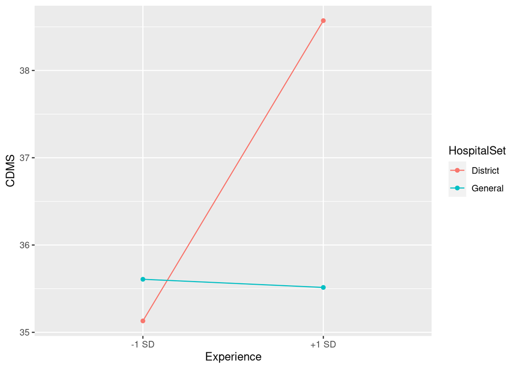

```r
graph_model(
  model = L3.int,
  y = CDMS,
  x = Experience,
  lines = HospitalSet,
  errorbars = "none")
```